# 201.1. Alert packets

For the Rubin Science Platform at data.lsst.cloud.  
Data Release: [Prompt Products](https://prompt-products.lsst.io/)  
Container Size: Large  
LSST Science Pipelines version: r30.0.11  
Last verified to run: 2026-09-03  
Repository: github.com/lsst/tutorial-notebooks  
DOI: 10.11578/rubin/dc.20250909.20

**Learning objective:** Understand the contents of the alert packets (in Avro format).

**LSST data products:** Alert packets.

**Packages:** `lsst.rsp.RSPClient`, `lsst.rsp.get_service_url`, `fastavro`.

**Credit:** Originally developed by Rubin Data Management team members. Please consider acknowledging them if this notebook is used for the preparation of journal articles, software releases, or other notebooks.

**Get Support:** Everyone is encouraged to ask questions or raise issues in the [Support Category](https://community.lsst.org/c/support) of the Rubin Community Forum. Rubin staff will respond to all questions posted there.

## 1. Introduction

**An alert packet** is a file that contains measurements for sources detected in difference images. Alerts are streamed to **brokers** within a few minutes of the acquisition of every new image to enable real-time analysis and spectroscopic follow-up, and brokers are the recommended way to do time-domain science with alerts. Alerts are world public and have no proprietary period.

**Alert packets are generated by the Alert Production pipeline**, which runs **Difference Image Analysis (DIA)** for each new exposure, provided a template image exists for that sky location. The template image is subtracted from the new processed visit image (the 'science' image) to produce a difference image. Source detection is run on the difference image, and every source (positive or negative) detected with signal-to-noise ratio $\geq 5$ becomes a `diaSource`. Every `diaSource` is associated with either a `diaObject` (static sky coordinates) or an `ssObject` (Solar System object). One alert is created per `diaSource`.

**What is included in an alert packet?**  
Alert packets include the following information, and much more. See [the Prompt Products documentation](https://prompt-products.lsst.io/products/alerts/index.html#contents) for a more complete list.

1. The triggering `diaSource` record, which includes photometric and astrometric measurements and metadata.
2. The associated `diaObject` or `mpc_orbit` record, which includes derived properties for the object.
3. Previous `diaSource` records associated with the `diaObject` from the last 12 months, maximum.
4. Image cutouts (stamps) from the science, template, and difference images, for the triggering `diaSource`.

**How do alerts relate to Rubin's other Prompt Products?**  
The data in the alert packets will also be stored in a queryable database, the Prompt Products Database (PPDB), which will update on a ~24-hour timescale and will be available via the Rubin Science Platform (RSP). The *contents* of the PPDB are public but RSP access is not (unlike broker access). The processed visit images and difference images become available via the RSP after an 80-hour embargo, and are subject to the two-year proprietary period. (See the [Rubin Data Policy](https://rubinobservatory.org/for-scientists/data-products/data-policy).)

**Additional resources:**

- [Alert Production database schema](https://sdm-schemas.lsst.io/apdb.html).
- [Prompt Products documentation](https://prompt-products.lsst.io/).
- [Learn more about the LSST alert brokers](https://rubinobservatory.org/for-scientists/data-products/alerts-and-brokers).

**This tutorial** focuses on the details of the packets' schema and data contents, and how packets for static-sky and moving objects differ.

**Related tutorials:** The 100-level tutorial on the alert retrieval service focuses on how the service works, and options for packet retrieval formats (e.g., FITS, JSON, schema-only, cutouts-only).

### 1.1. Import packages

Import the `fastavro` package for reading alerts from the alert retrieval service in the default Avro format. Import the `RSPClient` and `get_service_url` in order to access the alert retrieval service. Also import a range of other plotting and analysis packages.

```python
import fastavro
import matplotlib.pyplot as plt
import pandas as pd
import io
from astropy.io import fits
from astropy.wcs import WCS
from astropy.coordinates import SkyCoord
from astropy.nddata import CCDData
from astropy.visualization import (MinMaxInterval, ZScaleInterval,
                                   AsinhStretch, LinearStretch,
                                   ImageNormalize)
from astropy.wcs.utils import skycoord_to_pixel
from reproject.mosaicking import find_optimal_celestial_wcs
from reproject import reproject_exact

from lsst.rsp import RSPClient, get_service_url
from lsst.utils.plotting import (get_multiband_plot_colors,
                                 get_multiband_plot_symbols)
```

### 1.2. Define parameters

Establish the connection to the alert retrieval service by getting the `url` for the service and instantiating the `RSPClient`.

```python
url = get_service_url("alerts", "prompt")
client = RSPClient("")
```

Use the recommended colorblind-friendly palette to represent Rubin filters.

```python
filter_colors = get_multiband_plot_colors()
filter_names = list(filter_colors.keys())
filter_symbols = get_multiband_plot_symbols()
```

## 2. Avro alert packets

The "alert ID" is the same as the `diaSourceId` of the triggering difference-image detection.

The alert brokers were used to browse LSST alerts and find example alerts for two different types of time-domain objects.

**A static-sky source alert:** The detection of Type Ia supernova (SNIa) [SN 2026ivl](https://www.wis-tns.org/object/2026ivl) in an LSST image on MJD $= 61152.083609$.  
`snia_alert_id` $= 170301167371288762$

**A solar system source alert:** The detection of main-belt asteroid (MBA) 2015 BC557 / 713454 (designation K15Bt7C) in an LSST image on MJD $= 61098.241373$.  
`mba_alert_id` $= 170063717265309728$

Establish the `alert_id` values to use for the SNIa and MBA.

```python
snia_alert_id = "170301167371288762"
mba_alert_id = "170063717265309728"
```

### 2.1. Retrieve the packets

An Avro Object Container File (OCF) is the default response format from the alert retrieval service. Other formats (JSON, FITS) are possible, as demonstrated in the 100-level tutorial on the alert retrieval service.

Pass the `url` to the `client` along with the `alert_id`. Use the `await` command to pause execution of the cell's code until a response is received, then show the `response`. Retrieve the alert for the `snia_alert_id`.

```python
snia_response = await client.get(url, params={"ID": snia_alert_id})
snia_response?
```

```
Type:        Response
String form: <Response [200 OK]>
File:        /opt/lsst/software/stack/conda/envs/lsst-scipipe-12.3.0-exact/lib/python3.13/site-packages/httpx/__init__.py
Docstring:   <no docstring>
```

If an incorrect alert ID is used the `client.get` call will still execute, but a "404 Not Found" error message will appear next to "String form:" in the above output and in the output of the following cell instead of "200 OK".

```python
snia_response.raise_for_status()
```

```
<Response [200 OK]>
```

Also retrieve the alert for the `mba_alert_id`.

```python
mba_response = await client.get(url, params={"ID": mba_alert_id})
mba_response.raise_for_status()
```

```
<Response [200 OK]>
```

Show that the Avro OCF container file for the SNIa is larger than that for the MBA. The bulk of the packet size is the cutout images, and different objects will have different packet sizes mainly due to having different detection histories.

```python
print(f"SNIa Avro OCF size: {len(snia_response.content):,} bytes")
print(f"MBA Avro OCF size: {len(mba_response.content):,} bytes")
```

```
SNIa Avro OCF size: 177,066 bytes
MBA Avro OCF size: 135,154 bytes
```

Read the Avro packet with `fastavro.reader`.

```python
snia_avro = fastavro.reader(io.BytesIO(snia_response.content))
mba_avro = fastavro.reader(io.BytesIO(mba_response.content))
```

### 2.2. Packet schema

The `fastavro.reader` used above reads the embedded schema automatically.

Extract the schema, and show that the keys and fields are the same for each (but for triggering `diaSources` that are associated with a `diaObject` instead of a `ssObject`, the fields `ssSource` and `mpc_orbits` won't be populated).

```python
snia_schema = snia_avro.writer_schema
print("SNIa packet")
print(f" keys: {snia_schema.keys()}")
print(f" fields: {[f['name'] for f in snia_schema['fields']]}")
print()
mba_schema = mba_avro.writer_schema
print("MBA packet")
print(f" keys: {mba_schema.keys()}")
print(f" fields: {[f['name'] for f in mba_schema['fields']]}")
```

```
SNIa packet
 keys: dict_keys(['type', 'name', 'fields'])
 fields: ['diaSourceId', 'observation_reason', 'target_name', 'diaSource', 'prvDiaSources', 'prvDiaForcedSources', 'diaObject', 'ssSource', 'mpc_orbits', 'cutoutDifference', 'cutoutScience', 'cutoutTemplate']

MBA packet
 keys: dict_keys(['type', 'name', 'fields'])
 fields: ['diaSourceId', 'observation_reason', 'target_name', 'diaSource', 'prvDiaSources', 'prvDiaForcedSources', 'diaObject', 'ssSource', 'mpc_orbits', 'cutoutDifference', 'cutoutScience', 'cutoutTemplate']
```

The [Alert Production Database table schema](https://sdm-schemas.lsst.io/apdb.html) provides a browsable interface to the alert schema.

Option to print the entire schema.

```python
# snia_schema
```

```python
# mba_schema
```

### 2.3. Packet records

Extract the packet record as the first (and only) row of a `list` generated from the Avro OCF.

```python
snia_records = list(snia_avro)
snia_record = snia_records[0]

mba_records = list(mba_avro)
mba_record = mba_records[0]
```

Show that the record's keys are the same as the packet's fields (this is true also for `mba_record`).

```python
snia_record.keys()
```

```
dict_keys(['diaSourceId', 'observation_reason', 'target_name', 'diaSource', 'prvDiaSources', 'prvDiaForcedSources', 'diaObject', 'ssSource', 'mpc_orbits', 'cutoutDifference', 'cutoutScience', 'cutoutTemplate'])
```

The first three are:

- `diaSourceId`: ID of the triggering `diaSource`.
- `observation_reason`: Mode of the Rubin scheduler when the observation was obtained.
- `target_name`: Name of the field targeted by the observation, e.g., a deep drilling field (DDF), the low-dust wide-fast-deep region (lowdust).

Print the values of the first three keys in the record for each object.

```python
print("SNIa record")
print(f" diaSourceId: {snia_record['diaSourceId']}")
print(f" observation_reason: {snia_record['observation_reason']}")
print(f" target_name: {snia_record['target_name']}")
print()
print("MBA record")
print(f" diaSourceId: {mba_record['diaSourceId']}")
print(f" observation_reason: {mba_record['observation_reason']}")
print(f" target_name: {mba_record['target_name']}")
```

```
SNIa record
 diaSourceId: 170301167371288762
 observation_reason: ddf_cosmos
 target_name: lowdust, ddf_cosmos

MBA record
 diaSourceId: 170063717265309728
 observation_reason: alert_m49
 target_name: field_m49, lowdust
```

### 2.4. Triggering diaSource

The `diaSource` field contains the full record of the triggering difference image detection.

[DiaSource table schema](https://sdm-schemas.lsst.io/apdb.html#DiaSource)

Extract the `diaSource` for each of the objects.

```python
snia_diaSource = snia_record['diaSource']
mba_diaSource = mba_record['diaSource']
```

Option to print the keys of `diaSource`, which are the same for all objects.

```python
# snia_diaSource.keys()
```

Key columns include:

- `band`: LSST filter of the observation, one of: $ugrizy$.
- `midpointMjdTai`: The MJD at the midpoint of the exposure.
- `psfFlux`, `psfFluxErr`: The PSF flux and its error, measured on the difference image, in nJy.
- `scienceFlux`, `scienceFluxErr`: The PSF flux and its error, measured on the science image, in nJy.

> **Warning:** while the science flux is useful for variable stars, for supernovae it is typically contaminated by host galaxy light and is inappropriate for use in a lightcurve.

Print the values in the key columns.

```python
print("SNIa diaSource")
print(f" diaSource['band']: {snia_diaSource['band']}")
print(f" diaSource['midpointMjdTai']: {snia_diaSource['midpointMjdTai']}")
print(f" diaSource['psfFlux']: {snia_diaSource['psfFlux']}")
print(f" diaSource['scienceFlux']: {snia_diaSource['scienceFlux']}")
print()
print("MBA diaSource")
print(f" diaSource['band']: {mba_diaSource['band']}")
print(f" diaSource['midpointMjdTai']: {mba_diaSource['midpointMjdTai']}")
print(f" diaSource['psfFlux']: {mba_diaSource['psfFlux']}")
print(f" diaSource['scienceFlux']: {mba_diaSource['scienceFlux']}")
```

```
SNIa diaSource
 diaSource['band']: r
 diaSource['midpointMjdTai']: 61152.0836086934
 diaSource['psfFlux']: 90499.59375
 diaSource['scienceFlux']: 101317.328125

MBA diaSource
 diaSource['band']: r
 diaSource['midpointMjdTai']: 61098.24137255241
 diaSource['psfFlux']: 7202.36572265625
 diaSource['scienceFlux']: 7502.54541015625
```

### 2.5. Associated object

The `diaObject` and `mpc_orbits`/`ssSource` fields contain information about the associated static-sky time-domain object or the moving object, respectively.

Demonstrate that the `snia_record` is associated with a static-sky time-domain object, and the `mba_record` with a moving object, as expected.

```python
if (snia_record['diaObject'] is not None) & (snia_record['mpc_orbits'] is None):
    print('The snia_record is associated with a static-sky object.')
if (mba_record['diaObject'] is None) & (mba_record['mpc_orbits'] is not None):
    print('The mba_record is associated with a moving object.')
```

```
The snia_record is associated with a static-sky object.
The mba_record is associated with a moving object.
```

#### 2.5.1. DIA object (static-sky)

The `diaObject` contains aggregate information about the static-sky time-domain object, based on all the previous detections plus the triggering detection.

[DiaObject table schema](https://sdm-schemas.lsst.io/apdb.html#DiaObject)

For the SNIa, extract the `diaObject` record.

```python
snia_diaObject = snia_record['diaObject']
```

Option to print the keys of `snia_diaObject`.

```python
# snia_diaObject.keys()
```

Key columns include:

- `diaObjectId`: Unique ID of the `diaObject`.
- `ra`, `dec`: Sky coordinates for the `diaObject`, in degrees.
- `nDiaSources`: Number of detections, total (over all filters), including the triggering detection.

Lightcurve characterization parameters such as the minimum, maximum, mean, and standard deviation in the flux values, plus the number of measurements, for the PSF flux (detection in the difference image), PSF forced flux (forced on the difference image), and the science flux (PSF photometry on the science image), for each filter, are also available. Flux values are in nJy.

Print a few of the key column values.

```python
columns = ["diaObjectId", "ra", "dec", "nDiaSources", "r_psfFluxMean"]
for col in columns:
    print(f"{col: <22} {snia_diaObject[col]}")
```

```
diaObjectId            170235219334922248
ra                     148.4742795954378
dec                    1.718237259899008
nDiaSources            34
r_psfFluxMean          25149.900390625
```

#### 2.5.2. MPC orbit (moving objects)

The `mpc_orbits` contains orbital elements and related information of known Solar System objects, from the Minor Planet Center (MPC) database.

[MPC orbits table schema](https://sdm-schemas.lsst.io/apdb.html#mpc_orbits)

For the MBA, extract the `mpc_orbits` record.

```python
mba_mpcOrbit = mba_record['mpc_orbits']
```

Option to print the keys of `mba_mpcOrbit`.

```python
# mba_mpcOrbit.keys()
```

Key columns include:

- `designation`: The MPC designation (name) of the associated moving object.
- `q`: MPC pericenter distance in au.
- `e`: MPC eccentricity.
- `i`: MPC inclination in degrees.
- `h`: MPC H magnitude.

Print a few of the key column values.

```python
columns = ["designation", "q", "e", "i", "h"]
for col in columns:
    print(f"{col: <22} {mba_mpcOrbit[col]}")
```

```
designation            2015 BC557
q                      2.12651755819726
e                      0.090786802364178
i                      6.9786091591327
h                      18.462
```

#### 2.5.3. SS source (moving objects)

The `ssSource` contains computed quantities at the time of the triggering alert.

[ssSource table schema](https://sdm-schemas.lsst.io/apdb.html#SSSource)

For the MBA, extract the `ssSource` record.

```python
mba_ssSource = mba_record['ssSource']
```

Option to print the keys of `ssSource`.

```python
# mba_ssSource.keys()
```

Key columns include:

- `ssObjectid`: Unique ID in the `ssObject` table.
- `phaseAngle`: Phase angle between the Sun, object, and observer, in degrees.
- `eclBeta`, `eclLambda`: The ecliptic latitude and longitude, in degrees.
- `elongation`: Solar elongation, in degrees.
- `ephVmag`: Predicted magnitude in V band.

The heliocentric and topocentric positions and velocities (`helio_` and `topo_` `x`, `y`, `z`, `vx`, `vy`, `vz`) are also included, among other parameters.

Print a few of the key column values.

```python
columns = ["ssObjectId", "phaseAngle", "eclBeta", "eclLambda", "elongation", "ephVmag"]
for col in columns:
    print(f"{col: <12} {mba_ssSource[col]}")
```

```
ssObjectId   21164728071239491
phaseAngle   10.14724349975586
eclBeta      9.892962667410773
eclLambda    181.76689955148512
elongation   154.61837768554688
ephVmag      0.0
```

### 2.6. Lightcurves

If they are not `None`, the `prvDiaSources` and `prvDiaForcedSources` fields contain the history of past detections and forced PSF photometry measurements, respectively.

Currently, past detections and forced photometry is not available for moving objects, only for static-sky objects.

Show the number of previous sources and forced sources for the two objects.

```python
print("SNIa record")
if snia_record['prvDiaSources'] is not None:
    print(f" Number of previous detections: {len(snia_record['prvDiaSources'])}")
else:
    print(" No previous detections")
if snia_record['prvDiaForcedSources'] is not None:
    print(f" Number of forced photometry measurements: {len(snia_record['prvDiaForcedSources'])}")
else:
    print(" No forced photometry measurements")
print()
print("MBA record")
if mba_record['prvDiaSources'] is not None:
    print(f" Number of previous detections: {len(mba_record['prvDiaSources'])}")
else:
    print(" No previous detections")
if mba_record['prvDiaForcedSources'] is not None:
    print(f" Number of forced photometry measurements: {len(mba_record['prvDiaForcedSources'])}")
else:
    print(" No forced photometry measurements")
```

```
SNIa record
 Number of previous detections: 33
 Number of forced photometry measurements: 39

MBA record
 No previous detections
 No forced photometry measurements
```

To plot the lightcurve for a static-sky object, start by extracting the current and past photometry from the records.

Get the band, MJD, and PSF difference-image flux for the triggering detection.

```python
alert_band = str(snia_diaSource['band'])
alert_mjd = float(snia_diaSource['midpointMjdTai'])
alert_flux = float(snia_diaSource['psfFlux'])
```

Create `pandas` dataframes of the previous detections.

```python
df = pd.DataFrame(snia_record['diaSource'], index=[0])
df_prv = pd.DataFrame(snia_record['prvDiaSources'])
df_lc = pd.concat([df, df_prv], ignore_index=True)

del df, df_prv
```

Create `pandas` dataframes of the forced PSF photometry on the past images, which includes the image with the triggering detection.

```python
df = pd.DataFrame(snia_record['diaSource'], index=[0])
df_prv = pd.DataFrame(snia_record['prvDiaForcedSources'])
df_flc = pd.concat([df, df_prv], ignore_index=True)

del df, df_prv
```

Plot separately the lightcurves using the detections (plus the triggering detection), and using the forced photometry.

The fluxes in the g, r, and i bands overlap, so impose a flux offset by filter when plotting.

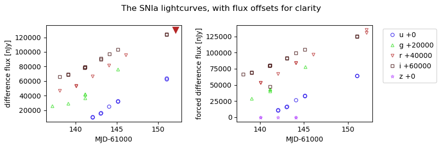

```python
offsets = [0, 20000, 40000, 60000, 0, 0]

fig, ax = plt.subplots(1, 2, figsize=(9, 3))
for f, filt in enumerate(filter_names):
    if alert_band == filt:
        ax[0].plot(alert_mjd-61000, alert_flux+offsets[f], filter_symbols[filt], ms=7,
                   mew=2, alpha=1, color=filter_colors[filt])
    df_pick_band = df_lc.loc[df_lc['band'] == filt]
    if len(df_pick_band) > 0:
        ax[0].plot(df_pick_band['midpointMjdTai']-61000, df_pick_band['psfFlux']+offsets[f],
                   filter_symbols[filt], ms=5, mew=1, alpha=0.7, mec=filter_colors[filt],
                   color='None')
    df_pick_band = df_flc.loc[df_flc['band'] == filt]
    if len(df_pick_band) > 0:
        ax[1].plot(df_pick_band['midpointMjdTai']-61000, df_pick_band['psfFlux']+offsets[f],
                   filter_symbols[filt], ms=5, mew=1, alpha=0.7, mec=filter_colors[filt],
                   color='None', label=filt + " +" + str(offsets[f]))
ax[0].set_xlabel('MJD-61000')
ax[1].set_xlabel('MJD-61000')
ax[0].set_ylabel('difference flux [nJy]')
ax[1].set_ylabel('forced difference flux [nJy]')
ax[1].legend(bbox_to_anchor=(1.05, 1), handletextpad=0, loc='upper left')
plt.suptitle('The SNIa lightcurves, with flux offsets for clarity')
plt.tight_layout()
plt.show()
```

> **Figure 1:** At left, the difference-image detection flux as a function of MJD (open symbols), plus the triggering alert detection (filled symbol). At right, the difference-image forced photometry fluxes as a function of MJD, which includes a forced measurement in the triggering observation. Fluxes have been offset in the g, r, and i filters for clarity, as indicated in the legend.

### 2.7. Image stamps (cutouts)

Small image stamps (cutout images) from the science, template, and difference image are embedded in every alert.

Use the `fits` package to convert the string-format image for the SNIa science stamp into a Header Data Unit List (HDUL), and print the names of each HDU.

```python
sci_hdul = fits.HDUList.fromstring(snia_record['cutoutScience'])
for hdu in sci_hdul:
    print(hdu.name)
```

```
PRIMARY
UNCERT
PSFIMAGE
```

Extract the primary HDU and display the header. Notice the pixel flux units (BUNIT) is in nJy, and that the WCS is included.

```python
pri_sci_hdu = sci_hdul['PRIMARY']
pri_sci_hdu.header
```

```
SIMPLE  =                    T / conforms to FITS standard
BITPIX  =                  -32 / array data type
NAXIS   =                    2 / number of array dimensions
NAXIS1  =                   51
NAXIS2  =                   51
EXTEND  =                    T
CUTMINX =                 2874
CUTMINY =                 2784
ROTPA   =     17.0390078992157 / Pos angle in deg of focal plane +Y wrt North
BUNIT   = 'nJy     '
WCSAXES =                    2 / Number of coordinate axes
CRPIX1  =      25.981179621249 / Pixel coordinate of reference point
CRPIX2  =      26.339120759041 / Pixel coordinate of reference point
PC1_1   = -5.3000516248565E-05 / Coordinate transformation matrix element
PC1_2   =  1.6186434587101E-05 / Coordinate transformation matrix element
PC2_1   =  1.6276853088302E-05 / Coordinate transformation matrix element
PC2_2   =  5.3082632371196E-05 / Coordinate transformation matrix element
CDELT1  =                  1.0 / Coordinate increment at reference point
CDELT2  =                  1.0 / Coordinate increment at reference point
CRVAL1  =      148.47427912183 / Coordinate value at reference point
CRVAL2  =      1.7182357179183 / Coordinate value at reference point
LATPOLE =                 90.0 / [deg] Native latitude of celestial pole
MJDREF  =                  0.0 / [d] MJD of fiducial time
```

Get the SNIa stamp's World Coordinate System (WCS). Add in the missing `ctype` that is needed in order to use the WCS to convert between sky and pixel coordinates (this missing piece of FITS header information will be fixed soon). Use the RA and Dec of the SNIa from its [Transient Name Server page](https://www.wis-tns.org/object/2026ivl), and convert it to pixels.

```python
wcs = WCS(pri_sci_hdu.header)
wcs.wcs.ctype = ["RA---TAN", "DEC--TAN"]
snia_ra = 148.474283
snia_dec = +1.718233
coord = SkyCoord(snia_ra, snia_dec, unit="deg")
pixels = skycoord_to_pixel(coord, wcs, origin=0)
```

Also define the pixels for a point 4" north of the SNIa.

```python
temp_dec = snia_dec + 4.0/3600.0
temp_coord_N = SkyCoord(snia_ra, temp_dec, unit="deg")
temp_pixels_N = skycoord_to_pixel(temp_coord_N, wcs, origin=0)
```

Display the image stamps for the SNIa. Several options for the image scaling are provided as commented-out code lines.

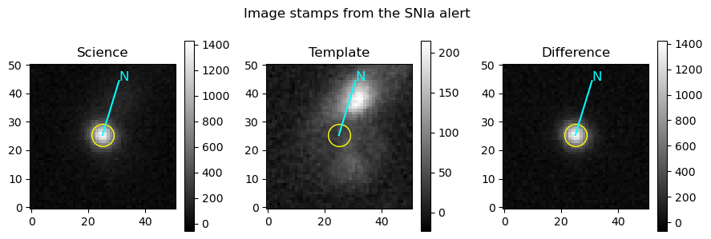

```python
stamps = [snia_record['cutoutScience'],
          snia_record['cutoutTemplate'],
          snia_record['cutoutDifference']]
stamp_names = ['Science', 'Template', 'Difference']

fig, ax = plt.subplots(1, 3, figsize=(9, 3))
for s, (stamp, name) in enumerate(zip(stamps, stamp_names)):
    hdul = fits.HDUList.fromstring(stamp)
    data = hdul[0].data
    image = CCDData(data.astype("float32"), unit='nJy')
#     norm = ImageNormalize(image, interval=ZScaleInterval(),
#                           stretch=AsinhStretch())
#     norm = ImageNormalize(image, interval=ZScaleInterval(),
#                           stretch=LinearStretch())
    norm = ImageNormalize(image, interval=MinMaxInterval(),
                          stretch=LinearStretch())
    plt.sca(ax[s])
    plt.imshow(image, origin='lower', norm=norm, cmap='gray')
    plt.colorbar()
    ax[s].set_title(name)
    plt.plot(pixels[0], pixels[1], 'o', ms=20, mew=1, color='None', mec='yellow')
    plt.plot([pixels[0], temp_pixels_N[0]], [pixels[1], temp_pixels_N[1]], color='cyan')
    plt.text(temp_pixels_N[0], temp_pixels_N[1], 'N', color='cyan', fontsize=12)
    ax[s].set_title(name)
plt.suptitle('Image stamps from the SNIa alert')
plt.tight_layout()
plt.show()
```

> **Figure 2:** Image stamps from the SNIa alert packet. The literature coordinates of the SNIa are marked with a yellow circle, and the north direction indicated with a cyan line.

Display the image stamps for the MBA.

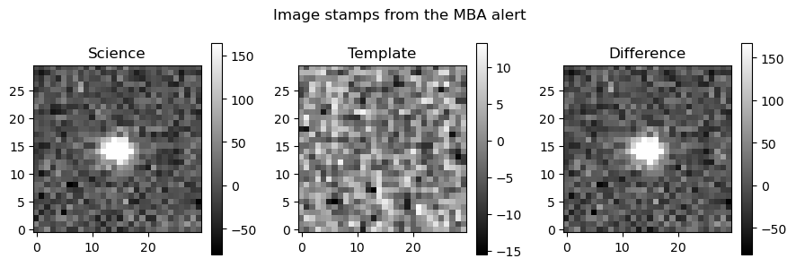

```python
stamps = [mba_record['cutoutScience'],
          mba_record['cutoutTemplate'],
          mba_record['cutoutDifference']]

fig, ax = plt.subplots(1, 3, figsize=(9, 3))
for s, (stamp, name) in enumerate(zip(stamps, stamp_names)):
    hdul = fits.HDUList.fromstring(stamp)
    data = hdul[0].data
    image = CCDData(data.astype("float32"), unit='nJy')
    norm = ImageNormalize(image, interval=ZScaleInterval(),
                          stretch=LinearStretch())
    plt.sca(ax[s])
    plt.imshow(image, origin='lower', norm=norm, cmap='gray')
    plt.colorbar()
    ax[s].set_title(name)
plt.suptitle('Image stamps from the MBA alert')
plt.tight_layout()
plt.show()
```

> **Figure 3:** Image stamps from the MBA alert packet.

#### 2.7.1. Rotate stamps to display north-up, east-left

In Figures 2 and 3 above, the image stamps are displayed at the camera's rotation angle. This section demonstrates how to rotate the stamps to display with the convention of north-up, east-left.

Use the three image stamps for the SNIa.

```python
stamps = [snia_record['cutoutScience'],
          snia_record['cutoutTemplate'],
          snia_record['cutoutDifference']]
stamp_names = ['Science', 'Template', 'Difference']
```

Use the `data` and `wcs` from the first stamp, `stamps[0]`, and the `find_optimal_celestial_wcs` from the `reproject` package to get a new WCS object and image shape that have RA and Dec aligned with the conventional North (up) and East (left) projection for the SNIa alert fits images. As above, correct for missing values in the WCS `ctype`.

> **Warning:** If the WCS `ctype` correction is not applied `find_optimal_celestial_wcs` will fail with TypeError: WCS does not have celestial components.

```python
hdul = fits.HDUList.fromstring(stamps[0])
data = hdul[0].data
wcs = WCS(hdul[0].header)
wcs.wcs.ctype = ["RA---TAN", "DEC--TAN"]

wcs_out, shape_out = find_optimal_celestial_wcs([(data, wcs)])
```

Get the pixel coordinates of the target and the North and East vectors in this new, reprojected WCS.

```python
pixels_reproj = skycoord_to_pixel(coord, wcs_out, origin=0)
temp_pixels_N_reproj = skycoord_to_pixel(temp_coord_N, wcs_out, origin=0)

temp_ra = snia_ra + 4.0/3600.0
temp_coord_E = SkyCoord(temp_ra, snia_dec, unit="deg")
temp_pixels_E_reproj = skycoord_to_pixel(temp_coord_E, wcs_out, origin=0)
```

Recreate Figure 2, but with the images displayed in the new north-up, east-left projection.

- Omit the colorbar because it is large; uncomment the line to display the colorbar again.
- Use of shorter variable names for the reprojected pixels is only to enable clearer, shorter plotting commands.

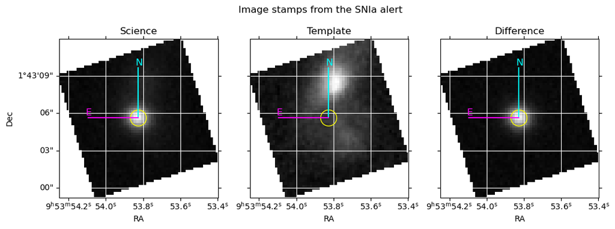

```python
pix = pixels_reproj
pix_N = temp_pixels_N_reproj
pix_E = temp_pixels_E_reproj

fig, ax = plt.subplots(1, 3, figsize=(12, 4), subplot_kw=dict(projection=wcs_out))
for s, (stamp, name) in enumerate(zip(stamps, stamp_names)):
    hdul = fits.HDUList.fromstring(stamp)
    data = hdul[0].data
    data_reproj, footprint = reproject_exact(input_data=(data, wcs), output_projection=wcs_out,
                                             shape_out=shape_out)
    image = CCDData(data_reproj.astype("float32"), unit="nJy")
    norm = ImageNormalize(image, interval=MinMaxInterval(), stretch=LinearStretch())
    plt.sca(ax[s])
    plt.imshow(image, origin='lower', norm=norm, cmap='gray')
    # plt.colorbar()

    plt.plot(pix[0], pix[1], 'o', ms=20, mew=1, color='None', mec='yellow')
    plt.plot([pix[0], pix_N[0]], [pix[1], pix_N[1]], color='cyan')
    plt.text(pix_N[0]-1, pix_N[1]+1, 'N', color='cyan', fontsize=12)
    plt.plot([pix[0], pix_E[0]], [pix[1], pix_E[1]], color='magenta')
    plt.text(pix_E[0]-1, pix_E[1]+1, 'E', color='magenta', fontsize=12)

    ax[s].grid(color='white', ls='solid')
    ax[s].set_xlabel('RA', fontsize=10)
    ax[s].tick_params(axis='x', labelsize=10)
    ax[s].set_ylabel('Dec', fontsize=10)
    ax[s].tick_params(axis='y', labelsize=10)
    if s > 0:
        ax[s].tick_params(axis='y', labelleft=False)
    ax[s].set_title(name)

plt.suptitle('Image stamps from the SNIa alert')
plt.show()
```

> **Figure 4:** Image stamps from the SNIa alert packet, reprojected such that North is up and East is left as indicated by the gridlines. The literature coordinates of the SNIa are marked with a yellow circle, and the North - East directions are indicated with cyan and magenta lines respectively.

#### 2.7.2. Update the FITS header

Above, the WCS `ctype` is corrected in order to display the image stamp. The following demonstrates how to propagate that change to the WCS into the FITS header `hdul`. Every change made to the header of each image stamp is printed as output of the next cell.

A FITS file with the updated header can be saved to file by uncommenting the "`hdule.writeto()`" line. The filenames will be, e.g., "170301167371288762_Difference.fits".

> **Warning:** `output_verify='ignore'` is required to save the modified header to file.

```python
stamps = [snia_record['cutoutScience'],
          snia_record['cutoutTemplate'],
          snia_record['cutoutDifference']]
stamp_names = ['Science', 'Template', 'Difference']

for s, (stamp, name) in enumerate(zip(stamps, stamp_names)):
    print("{}:".format(name))
    hdul = fits.HDUList.fromstring(stamp)
    data = hdul[0].data
    hdr = hdul[0].header
    wcs = WCS(hdr)

    wcs.wcs.ctype = ["RA---TAN", "DEC--TAN"]
    hdr_wcs = wcs.to_header()
    for x in list(hdr_wcs.keys()):
        if x not in hdr:
            print("add {} = {}".format(x, hdr_wcs[x]))
            hdr[x] = (hdr_wcs[x], hdr_wcs.comments[x])
        else:
            if hdr_wcs[x] != hdr[x]:
                print("update {} = {} -> {}".format(x, hdr[x], hdr_wcs[x]))
                hdr[x] = (hdr_wcs[x], hdr_wcs.comments[x])
    hdul[0] = fits.PrimaryHDU(data, header=hdr)
    # hdul.writeto("{}_{}.fits".format(snia_alert_id, name), output_verify='ignore')
    print()
```

```
Science:
add CUNIT1 = deg
add CUNIT2 = deg
add CTYPE1 = RA---TAN
add CTYPE2 = DEC--TAN
add LONPOLE = 180.0
update LATPOLE = 90.0 -> 1.7182357179183
add RADESYS = ICRS

Template:
add CUNIT1 = deg
add CUNIT2 = deg
add CTYPE1 = RA---TAN
add CTYPE2 = DEC--TAN
add LONPOLE = 180.0
update LATPOLE = 90.0 -> 1.7182357179183
add RADESYS = ICRS

Difference:
add CUNIT1 = deg
add CUNIT2 = deg
add CTYPE1 = RA---TAN
add CTYPE2 = DEC--TAN
add LONPOLE = 180.0
update LATPOLE = 90.0 -> 1.7182357179183
add RADESYS = ICRS
```

With the header data unit corrected, it is possible to then use the `reproject` functions on the `hdul` directly, with the example code below, which may be more convenient for certain workflows.

```
wcs_out, shape_out = find_optimal_celestial_wcs([hdul], hdu_in=0)
data_reproj, footprint = reproject_exact(input_data=hdul, output_projection=wcs_out, shape_out=shape_out)
```